# Which type of sample, biopsy or peripheral blood, is a better predictor of kidney transplant success, and which gene is the most influential in determining success in the early stages?

KIDNEY P7 - Chanel, Aagrath and Manfred

28 May, 2023 23:49

# 1 Executive Summary

The survival rates of kidney transplant report stated that the rejection rate for grafts after the kidney transplant process is approximately 98.9% in the first year and gradually decreases to approximately 68.5% in the fifth year (Pakfetrat et al., 2022). When compared to the first stage after the transplant, this is considered to be a significant decrease. There are several factors contributing to the declining patient survival rates, including gene expression in patients and donors as well as the types of samples used to diagnose the rejection outcome.

To determine which sample types are the best predictors for both in-sample and out-of-sample data, cross-validation and SVM (Support Vector Machine) are used in machine learning deployment for prediction. Biopsy has a higher AUC of 0.9985 compared to Blood, which has a slightly lower AUC of 0.9950 for the In-Sample Roc curve.

# 2 Aim and Background

Despite numerous R programming tutorials, few target bioinformatics, especially non-university courses. This is concerning as most medical researchers lack time for upskilling at universities. Therefore we decided to create an app that would help determine whether blood or biopsy is a better indicator of kidney transplant success and educate medical researchers on how to do so as well. We decided to compare blood and biopsy as there are two primary methods utilized to analyze kidney transplant success and afterward conducted gene expression analysis to see which genes had the largest impact in a successful transplant. This leads us to the creation of R-MEDiK. The R-MEDiK App is a web application for studying and understanding factors influencing kidney sample selection in transplant success.

# 3 Methods - Part A

In this section, we describe our approach to predicting kidney transplant success using gene expression data. We collected gene expression data from both blood and biopsy samples of kidney transplant patients. Our goal was to develop models that can accurately classify patients as either having a stable outcome or experiencing rejection based on their gene expression profiles.

o Mean Accuracy Calculation: We employed cross-validation techniques to evaluate the mean accuracy of our models. By splitting the data into training and testing subsets, we assessed the average accuracy of our models in predicting rejection or stable outcomes on both the trained data (in-sample) and new, unseen data (out-of-sample).  In-sample Mean Accuracy: For in-sample evaluation, we performed cross-validation on the training dataset. This process involved dividing the data into folds, training the models on a subset of the folds, and evaluating their performance on the remaining fold. The in-sample mean accuracy was then calculated by averaging the accuracy across all folds.  Out-of-sample Mean Accuracy: To assess the generalizability of the models, we conducted out-of-sample evaluation. We applied the trained models to an independent testing dataset, which was not used during training. Cross-validation was performed on the testing dataset by dividing the data into folds, training the models on a subset of the folds, and evaluating their performance on the remaining fold. The out-of-sample mean accuracy was calculated by averaging the accuracy across all folds.  By comparing the in-sample and out-of-sample mean accuracy, we gained insights into the models’ performance on both the trained and unseen data, ensuring their robustness and generalizability.

o SVM Decision Boundary Visualization: To gain insights into the decision-making process of our models, we visualized the decision boundaries in the feature space using Principal Component Analysis (PCA). Due to samples and grid had an uneven sample and feature distribution, PCA allowed us to reduce datapoint dimensions in order to create the SVM decision boundary to observe how our models separate the classes based on gene expression patterns.

Our selection of these evaluation methodologies ensured a thorough assessment of our models’ performance, taking into consideration graphical, qualitative, and quantitative data.

# 4 Methods Part B

For question 1, the data is collected using a dataset from the allograft rejection spreadsheet, which contains all geo databases with accession IDs. This dataset was obtained from the Gene Expression Omnibus database and assigned to a Sydney student via the kidney project page on Canvas. Most geodatabases contain information about accession IDs such as feature data and phenodata. In this question, two microarray datasets have been chosen, with accession numbers GSE15296 and GSE34437. GEO15296 denotes the type of peripheral blood sample, whereas GSE34437 denotes the type of biopsy sample. GEO15296 contains the gene expression of 75 blood samples, 51 of which developed graft rejection and 24 of which had a stable graft as the outcome. GSE34437, on the other hand, contains 66 biopsy samples from 13 patients who developed graft rejection and 53 patients who had stable graft outcomes. According to these results, the rejection and stable outcomes are not equal in both datasets, and more analysis is required to ensure the data’s consistency. We aim to investigate which of these two samples is a better predictor of kidney transplant success in the early stages.

# 5 Results - Part A

# 6 Results - Part B

In this section we will describe the contents of the shiny app created for our product R-MEDiK.

List of stages in Shiny app: 1. Data collection 2. Data cleaning 3. Data wrangling 4. Exploratory Data Analysis 5. Data Evaluation

After this, we move on to the “Data Collection” tab. Step 1: Gathering Information about the Dataset, Step 2: Measuring information. In this step, we aim to measure the information corresponding to each selected sample type, we get this summary. Example: Total features: 54675 Total samples: 75 Rejection count: 51 Stable count: 24 Step 3: Challenges The list of challenges that will arise when integrating these columns into the data evaluation stage. Example: “Our Challenges: Rejection count (51) is higher than Stable count (24). Rejection and stable outcomes from this dataset are not equal. To check for normalisation in these unequal outcomes, we will need to go through cleaning, wrangling, and Exploratory Data Analysis. Next, proceed to the Data Cleaning stage.”

Now we move on to data cleaning. Step 1: Evaluating Feature Data (RAW) In this step, check for any missing or empty Gene symbols, IDs, or NA values in both raw feature data datasets. The user can choose from the sample types in the drop-down menus below based on their interests. Step 2: Filtering Options In this second step, researchers have to filter and combine Samplename or geo_accession and Gene Expression ID in PhenoData with ID in FeatureData in order to match ID in order to integrate Gene Symbol and other information. Also, any NA or empty rows are found and removed is applied. Further, converting the rejection and stable results into comparable circumstances using matrix functions for PhenoData. Afterward, we describe to the user how to filter options. Step 3: Transforming to Cleaned - Blood The third step involves applying to raw featureData all the filtering options mentioned in step 2 that are linked by ID with phenodata and featureData. To convert unclean data to clean data, the user can click the Apply Filter button.

The third stage, Data Wrangling consists of a single step where the researcher can map data into a structural format for analysis. Step 1: Analyzing Top expressed genes In this step, we want to reduce the size of the gene expression sample in order to figure out whether blood samples or biopsy are more accurate at predicting kidney transplants. We show the user the top 300 genes with different expression levels. Afterward, we provide the user the option to select the number of genes since the size of gene expression depends on your research question and goal.

Afterward, we move on to exploratory data analysis. Step 1: Finding General Patterns The process involved incorporating log-transformation for different blood and biopsy sample types as well as examining the distribution and normalization of the data. Afterward, we define a box plot to the user and display the output as can be seen in the example below: Example: Min. 1st Qu. Median Mean 3rd Qu. Max. 1.197 2.789 4.073 4.575 5.984 14.134

The fifth and final stage data evaluation determines the final outcome of the research question that has been addressed in stages one through four. It includes one step in which we have to examine the ROC curve, the in-sample and out-of-sample mean accuracy, and the accuracy summaries to determine which sample types, blood or biopsy, are better for predicting kidney success. Step 1: Evaluating Machine Learning Models In this step, we will visually evaluate the roc curve as well as the in-sample and out-of-sample mean accuracy. Then, we’ll take a look at the statistical summaries of these two machine-learning models. In sample: Receiver Operating Characteristic (ROC) Curve we give the user sliders for False Positive Rate Range, and True Positive Rate Range. Distance Range including their definition to aid the user in understanding this statistical information. Underneath we include a summary of the ROC curve results for the user

In sample & Out sample: Mean Accuracy (%) In this section we define Mean accuracy which is a percentage that represents the average correctness of a model’s predictions.

After we give the users a Mean Accuracy Range which allows them to modify the mean accuracy parameters for both in-sample and out-of-sample mean accuracy using the slider options.

# 7 Discussion and conclusion

There are two significant limitations to this study’s analysis that are related to the use of SVM decision boundary methods and identifying the intersect genes with the greatest influence on the R-Medik shiny application product.

Blood and biopsy sample data frames were used in the SVM decision boundary from the out-of-sample training and testing set. Check the grid to make sure the sample taken from both samples is accurate and prepared for dimension reduction in the principal component. Match and trim training and testing tests using the row count () function if the row is unbalanced. The SVM model was used to visualise the decision boundary using PCA-transformed data and the mash grid function.

This whole concept was adapted from the textbook “ The Elements of Statistical Learning” (Hastie et al., 2017) in order to separate the two classes from the training set, which included rejection and stable outcomes in this case. The results of the decision boundary plot showed that there were patterns with accurate results, yet due to the PCA-transformed process had not fully adjusted the unclassified grid for biopsy sample, we were unable to determine how the relationship between rejection and stable can be used to predict new and unseen data.

Additionally, due to the complexity of the dataset’s columns and rows, decision boundary methods are considered as being too complex for blood and biopsy samples. A different approach to resolving these issues is presented in Slides 18–19 from the STAT3888: Statistical Machine Learning Material, which also provides descriptions of SVM decision boundary coding and strategies for coping with the complexity of data columns and rows (Ormerod, 2022). This study may apply these steps to further develop in the future work.

Furthermore, a few challenges are also present during the R-MEDiK shiny applications’ production stage. The initial goal of developing the application was to use different matrices to identify the best sample type and identify the gene expression for predicting the success of kidney transplants. Due to incomplete research regarding gene expression analysis, the application’s original goal was changed, and its current purpose is to offer tutorials on how to apply two machine learning models, such as the ROC curve and mean accuracy on in-sample and out-of-sample data modelling, in order to determine which sample types are the best predictors for a kidney transplant. As a result, only one question—“Determining sample type”—was added to the shiny application, which also only has two matrices and a sidebar with hard text. This was done due to there wasn’t enough information to add to the shiny application. Another opportunity exists here to expand upon current products in order to fulfill the application’s original intent in the future.

We were able to conclude after looking at data from 2 different datasets that biopsy is a better indicator of kidney transplant success, identify the top 8 most essential genes, and were able to fulfill our goal of building a shiny app for medical researchers. In future work we would like to add two more datasets for successful out-of-sample testing for increased accuracy of outcome, and in the shiny app, and include an upload CSV section for users to increase the usability for our app.

# 8 References

Hastie, T., Tibshirani, R., & Friedman, J. (2017). Springer Series in Statistics The Elements of Statistical Learning Data Mining, Inference, and Prediction Second Edition.https://hastie.su.domains/ElemStatLearn/printings/ESLII_print12_toc.pdf

Ormerod, J (2022). L17 - Support Vector Machines. STAT3888: Statistical Machine Learning [PowerPoint slides]. https://canvas.sydney.edu.au/groups/431912/files/31112278/download

Pakfetrat, M., Malekmakan, L., Jafari, N., & Sayadi, M. (2022). Survival Rate of Renal Transplant and Factors Affecting Renal Transplant Failure. Experimental and Clinical Transplantation, 20(3), 265–272. https://doi.org/10.6002/ect.2021.0430

Simplilearn. (2023, March 1). Top data science facts you should know about in 2023. Simplilearn.com. https://www.simplilearn.com/data-science-facts-article

# 9 Appendices

## 9.1 Figure1: Project Workflow Diagram

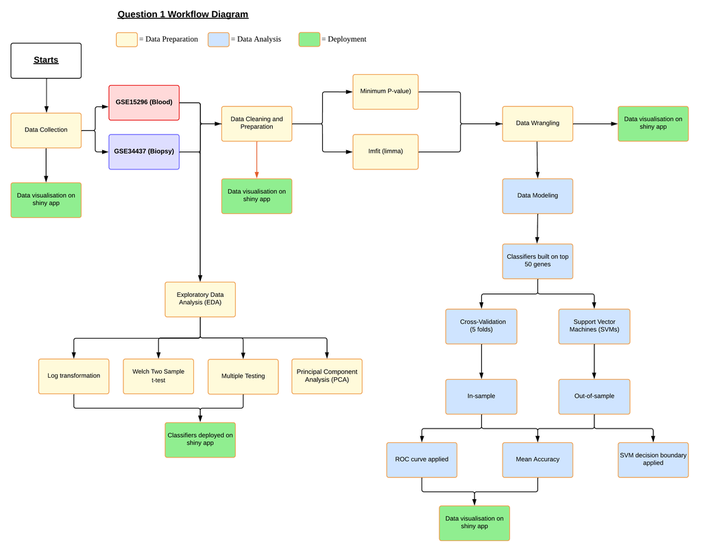

## 9.2 Figure2: In sample and Out of Sample Diagram

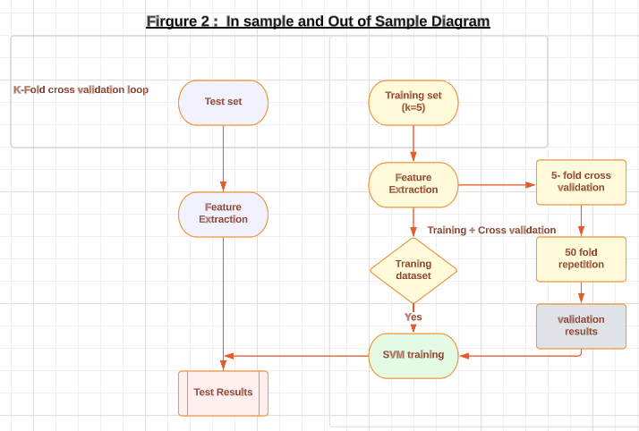

## 9.3 Figure3: ROC Curve

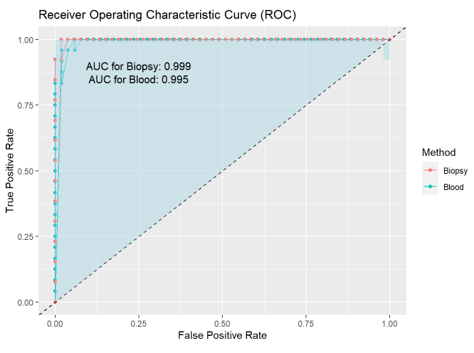

## 9.4 Figure4: In sample and out of sample Mena accuracy and 2 Extra datasets out of sample

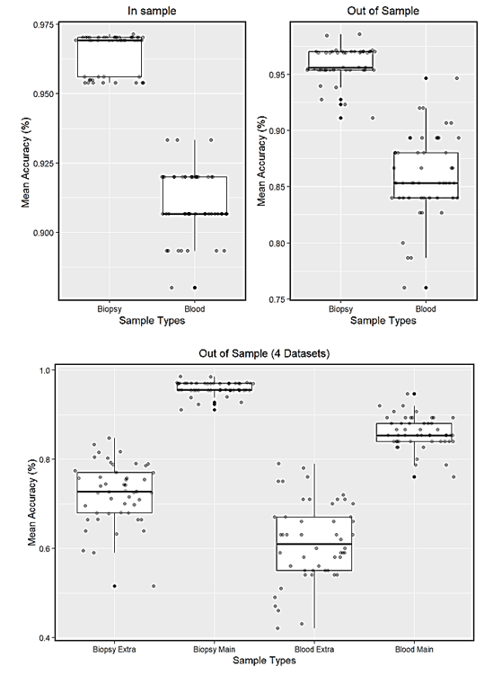

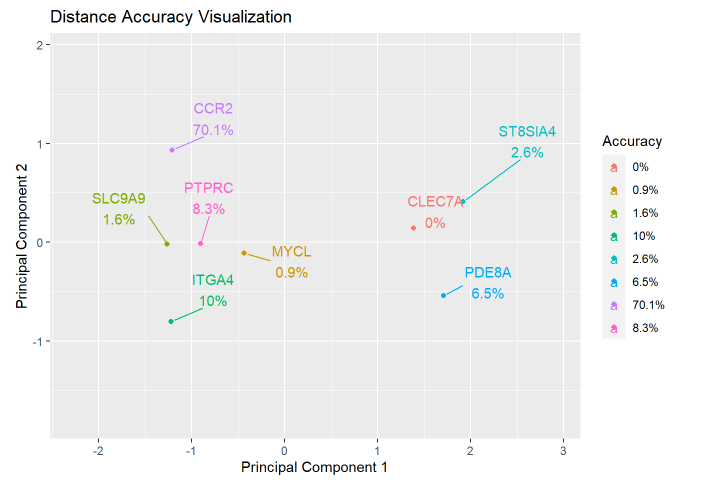

# 10 External Plots and Grapghs

## 10.1 SVM Decision Boundary

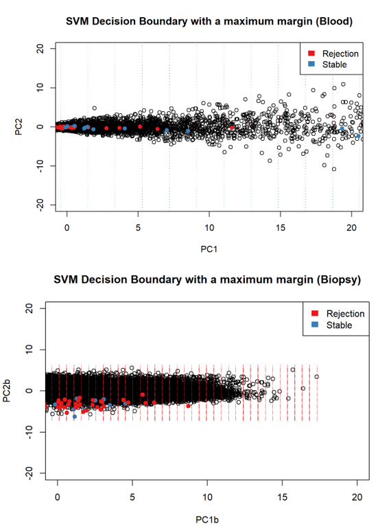

## 10.2 Top 8 Genes Heatmap

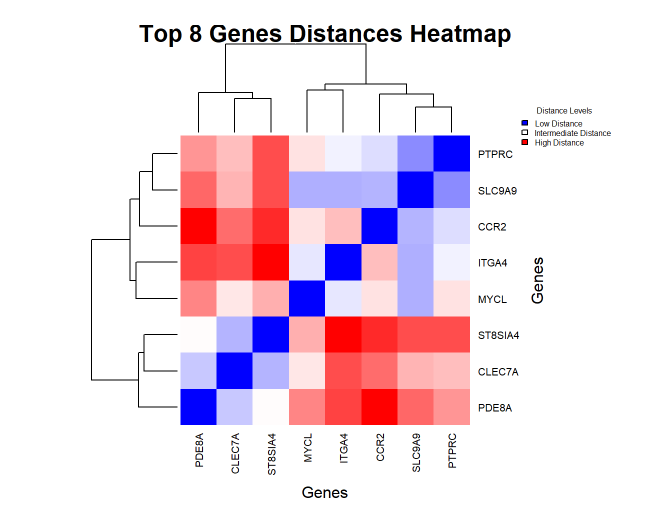

# 11 Report Contribution

Executive summary - Chanel

Aim and background - Aagrath

Method - Part A - Manfred

Method - Part B - Aagrath

Results - Part A - Manfred

Results - Part B - Aagrath

Discussion - Chanel

Conclusion - Aagrath

R-markdown/html report version - Chanel

# 12 Student contribution

“Throughout the course of the project, I have been developing a project analysis on Question 1 regarding which sample type—blood or biopsy—is a better indicator of kidney success. Participating in Kidney P7 Zoom meetings every Friday at 7 p.m., going to consultations, assisting with presentation slides, scripts, shiny workflow diagrams, and Q1 workflow diagrams, as well as developing Shiny tutorial applications and finishing the final report”. - Chanel Specter - 500436031

“I have contributed by developing Question 1 (Which sample type, blood or biopsy, is a better predictor of kidney success) attending all group meetings, attending multiple consultation appointments from week 9-13, working on the final report, working on shiny workflow diagram, Q1 workflow diagram, slides, and script for the presentation.”-490601909

Initially, I was developing question 2 of the project by deciding on a question and also searching for datasets that are suitable for our questions. Then, I participated in question 1 development and did a workflow diagram for question 1 and also for the shiny app. I participated in all Kidney P7 Zoom meetings on every Friday at 7 pm Sydney time and also went to consultations for question 1 and the Shiny app. I also assisted in completing the presentation slides, and scripts and designed the presentation slides’ layout. Furthermore, I helped to code a few layouts for Shiny tutorial applications and finished the final report (Method and Result for part A). - Yin You Manfred Koh 510668042